# Penguins 🐧

John Fiocca

What all can we learn about penguins?

## Summary

- Exploratory data analysis (EDA) of the Palmer Penguins dataset.
  - Data Visualization
    - Scatterplot Matrices
    - Correlation Matrices
  - Statistical Methods
    - Hypothesis Testing
      - T-Test
      - Chi2 Testing
- Model Building, Interpretation, and Validation
  - Linear Regression
  - Logistic Regression (Binary and Multinomial)
  - Unsupervised Learning (K-Means Clustering)

## First Waddles

```python
import matplotlib.pyplot as plt
import numpy as np
import pandas as pd
from scipy import stats
import statsmodels.api as sm
from statsmodels.stats.power import TTestIndPower, TTestPower
from statsmodels.stats.descriptivestats import describe
from sklearn import datasets, metrics, preprocessing
import seaborn as sns

%matplotlib inline
sns.set_theme()
```

```python
df = sns.load_dataset("penguins")

category_columns = df.select_dtypes("object").columns
df[category_columns] = df[category_columns].astype("category")
```

```python
df.info()
```

```
<class 'pandas.core.frame.DataFrame'>
RangeIndex: 344 entries, 0 to 343
Data columns (total 7 columns):
 #   Column             Non-Null Count  Dtype
---  ------             --------------  -----
 0   species            344 non-null    category
 1   island             344 non-null    category
 2   bill_length_mm     342 non-null    float64
 3   bill_depth_mm      342 non-null    float64
 4   flipper_length_mm  342 non-null    float64
 5   body_mass_g        342 non-null    float64
 6   sex                333 non-null    category
dtypes: category(3), float64(4)
memory usage: 12.3 KB
```

## Exploratory Data Analysis

### Numeric Methods

These Jarque-Bera statistics tells us that our variables aren't normally distributed. I suspect that species differences have something to do with this. Let's remember this for our modeling later.

```python
describe(df, categorical=False)
```

|  | bill_length_mm | bill_depth_mm | flipper_length_mm | body_mass_g |
| --- | --- | --- | --- | --- |
| nobs | 344.000000 | 344.000000 | 344.000000 | 344.000000 |
| missing | 2.000000 | 2.000000 | 2.000000 | 2.000000 |
| mean | 43.921930 | 17.151170 | 200.915205 | 4201.754386 |
| std_err | 0.295220 | 0.106785 | 0.760370 | 43.364735 |
| upper_ci | 44.500551 | 17.360464 | 202.405503 | 4286.747704 |
| lower_ci | 43.343308 | 16.941876 | 199.424906 | 4116.761068 |
| std | 5.459584 | 1.974793 | 14.061714 | 801.954536 |
| iqr | 9.275000 | 3.100000 | 23.000000 | 1200.000000 |
| iqr_normal | 6.875568 | 2.298033 | 17.049926 | 889.561331 |
| mad | 4.706797 | 1.663083 | 12.237133 | 676.395301 |
| mad_normal | 5.899095 | 2.084365 | 15.336972 | 847.735793 |
| coef_var | 0.124302 | 0.115140 | 0.069988 | 0.190862 |
| range | 27.500000 | 8.400000 | 59.000000 | 3600.000000 |
| max | 59.600000 | 21.500000 | 231.000000 | 6300.000000 |
| min | 32.100000 | 13.100000 | 172.000000 | 2700.000000 |
| skew | 0.052885 | -0.142835 | 0.344164 | 0.468264 |
| kurtosis | 2.119235 | 2.088845 | 2.012566 | 2.273757 |
| jarque_bera | 11.213802 | 12.993289 | 20.645710 | 20.014308 |
| jarque_bera_pval | 0.003672 | 0.001508 | 0.000033 | 0.000045 |
| mode | 41.100000 | 17.000000 | 190.000000 | 3800.000000 |
| mode_freq | 0.020468 | 0.035088 | 0.064327 | 0.035088 |
| median | 44.450000 | 17.300000 | 197.000000 | 4050.000000 |
| 1% | 34.041000 | 13.441000 | 178.000000 | 2900.000000 |
| 5% | 35.700000 | 13.900000 | 181.000000 | 3150.000000 |
| 10% | 36.600000 | 14.300000 | 185.000000 | 3300.000000 |
| 25% | 39.225000 | 15.600000 | 190.000000 | 3550.000000 |
| 50% | 44.450000 | 17.300000 | 197.000000 | 4050.000000 |
| 75% | 48.500000 | 18.700000 | 213.000000 | 4750.000000 |
| 90% | 50.800000 | 19.500000 | 220.900000 | 5400.000000 |
| 95% | 51.995000 | 20.000000 | 225.000000 | 5650.000000 |
| 99% | 55.513000 | 21.100000 | 230.000000 | 5979.500000 |

```python
describe(df, numeric=False)
```

|  | species | island | sex |
| --- | --- | --- | --- |
| nobs | 344 | 344 | 344 |
| missing | 0 | 0 | 11 |
| distinct | 3 | 3 | 2 |
| top_1 | Adelie | Biscoe | Male |
| top_2 | Gentoo | Dream | Female |
| top_3 | Chinstrap | Torgersen | None |
| top_4 | None | None | None |
| top_5 | None | None | None |
| freq_1 | 0.44186 | 0.488372 | 0.504505 |
| freq_2 | 0.360465 | 0.360465 | 0.495495 |
| freq_3 | 0.197674 | 0.151163 | NaN |
| freq_4 | NaN | NaN | NaN |
| freq_5 | NaN | NaN | NaN |

Species will be a major factor. Better JB normality after segmenting by it.

```python
df.groupby("species", observed=True).apply(
    describe, include_groups=False, categorical=False
).unstack(0)
```

| species | bill_length_mm Adelie | bill_length_mm Chinstrap | bill_length_mm Gentoo | bill_depth_mm Adelie | bill_depth_mm Chinstrap | bill_depth_mm Gentoo | flipper_length_mm Adelie | flipper_length_mm Chinstrap | flipper_length_mm Gentoo | body_mass_g Adelie | body_mass_g Chinstrap | body_mass_g Gentoo |
| --- | --- | --- | --- | --- | --- | --- | --- | --- | --- | --- | --- | --- |
| nobs | 152.000000 | 68.000000 | 124.000000 | 152.000000 | 68.000000 | 124.000000 | 152.000000 | 68.000000 | 124.000000 | 152.000000 | 68.000000 | 124.000000 |
| missing | 1.000000 | 0.000000 | 1.000000 | 1.000000 | 0.000000 | 1.000000 | 1.000000 | 0.000000 | 1.000000 | 1.000000 | 0.000000 | 1.000000 |
| mean | 38.791391 | 48.833824 | 47.504878 | 18.346358 | 18.420588 | 14.982114 | 189.953642 | 195.823529 | 217.186992 | 3700.662252 | 3733.088235 | 5076.016260 |
| std_err | 0.216745 | 0.404944 | 0.277882 | 0.099010 | 0.137687 | 0.088474 | 0.532173 | 0.864869 | 0.584731 | 37.317582 | 46.607475 | 45.454630 |
| upper_ci | 39.216203 | 49.627500 | 48.049516 | 18.540413 | 18.690450 | 15.155519 | 190.996683 | 197.518642 | 218.333043 | 3773.803369 | 3824.437207 | 5165.105698 |
| lower_ci | 38.366579 | 48.040147 | 46.960240 | 18.152302 | 18.150727 | 14.808709 | 188.910601 | 194.128417 | 216.040941 | 3627.521135 | 3641.739264 | 4986.926822 |
| std | 2.663405 | 3.339256 | 3.081857 | 1.216650 | 1.135395 | 0.981220 | 6.539457 | 7.131894 | 6.484976 | 458.566126 | 384.335081 | 504.116237 |
| iqr | 4.000000 | 4.725000 | 4.250000 | 1.500000 | 1.900000 | 1.500000 | 9.000000 | 10.000000 | 9.000000 | 650.000000 | 462.500000 | 800.000000 |
| iqr_normal | 2.965204 | 3.502648 | 3.150530 | 1.111952 | 1.408472 | 1.111952 | 6.671710 | 7.413011 | 6.671710 | 481.845721 | 342.851763 | 593.040887 |
| mad | 2.165072 | 2.755320 | 2.437835 | 0.963317 | 0.952941 | 0.811818 | 5.046182 | 5.534602 | 5.302267 | 374.882681 | 294.096021 | 423.431820 |
| mad_normal | 2.713515 | 3.453282 | 3.055373 | 1.207339 | 1.194335 | 1.017463 | 6.324451 | 6.936595 | 6.645406 | 469.845763 | 368.594701 | 530.693086 |
| coef_var | 0.068660 | 0.068380 | 0.064875 | 0.066316 | 0.061637 | 0.065493 | 0.034427 | 0.036420 | 0.029859 | 0.123915 | 0.102954 | 0.099313 |
| range | 13.900000 | 17.100000 | 18.700000 | 6.000000 | 4.400000 | 4.200000 | 38.000000 | 34.000000 | 28.000000 | 1925.000000 | 2100.000000 | 2350.000000 |
| max | 46.000000 | 58.000000 | 59.600000 | 21.500000 | 20.800000 | 17.300000 | 210.000000 | 212.000000 | 231.000000 | 4775.000000 | 4800.000000 | 6300.000000 |
| min | 32.100000 | 40.900000 | 40.900000 | 15.500000 | 16.400000 | 13.100000 | 172.000000 | 178.000000 | 203.000000 | 2850.000000 | 2700.000000 | 3950.000000 |
| skew | 0.160064 | -0.088564 | 0.643163 | 0.318039 | 0.006726 | 0.320263 | 0.086467 | -0.009262 | 0.390018 | 0.282494 | 0.241941 | 0.068783 |
| kurtosis | 2.808480 | 2.946321 | 4.196588 | 2.902197 | 2.101260 | 2.391607 | 3.281594 | 2.956063 | 2.399511 | 2.405611 | 3.463681 | 2.257871 |
| jarque_bera | 0.875558 | 0.097059 | 15.818100 | 2.605757 | 2.289089 | 3.999629 | 0.687059 | 0.006442 | 4.966349 | 4.231202 | 1.272569 | 2.919609 |
| jarque_bera_pval | 0.645468 | 0.952629 | 0.000367 | 0.271749 | 0.318369 | 0.135360 | 0.709263 | 0.996784 | 0.083478 | 0.120561 | 0.529255 | 0.232282 |
| mode | 41.100000 | 51.300000 | 45.200000 | 18.500000 | 17.300000 | 15.000000 | 190.000000 | 187.000000 | 215.000000 | 3550.000000 | 3400.000000 | 5000.000000 |
| mode_freq | 0.046358 | 0.044118 | 0.032520 | 0.059603 | 0.073529 | 0.081301 | 0.125828 | 0.088235 | 0.097561 | 0.052980 | 0.058824 | 0.048780 |
| median | 38.800000 | 49.550000 | 47.300000 | 18.400000 | 18.450000 | 15.000000 | 190.000000 | 196.000000 | 216.000000 | 3700.000000 | 3700.000000 | 5000.000000 |
| 1% | 33.300000 | 41.905000 | 41.766000 | 15.950000 | 16.467000 | 13.222000 | 175.000000 | 180.010000 | 207.220000 | 2875.000000 | 2834.000000 | 4111.000000 |
| 5% | 34.600000 | 42.745000 | 42.930000 | 16.550000 | 16.600000 | 13.610000 | 180.000000 | 185.700000 | 208.000000 | 3000.000000 | 3250.000000 | 4300.000000 |
| 10% | 35.500000 | 45.200000 | 43.520000 | 17.000000 | 16.770000 | 13.720000 | 181.000000 | 187.000000 | 209.000000 | 3150.000000 | 3300.000000 | 4400.000000 |
| 25% | 36.750000 | 46.350000 | 45.300000 | 17.500000 | 17.500000 | 14.200000 | 186.000000 | 191.000000 | 212.000000 | 3350.000000 | 3487.500000 | 4700.000000 |
| 50% | 38.800000 | 49.550000 | 47.300000 | 18.400000 | 18.450000 | 15.000000 | 190.000000 | 196.000000 | 216.000000 | 3700.000000 | 3700.000000 | 5000.000000 |
| 75% | 40.750000 | 51.075000 | 49.550000 | 19.000000 | 19.400000 | 15.700000 | 195.000000 | 201.000000 | 221.000000 | 4000.000000 | 3950.000000 | 5500.000000 |
| 90% | 42.100000 | 52.060000 | 50.800000 | 20.000000 | 19.900000 | 16.280000 | 198.000000 | 205.000000 | 228.000000 | 4300.000000 | 4195.000000 | 5700.000000 |
| 95% | 43.000000 | 53.255000 | 52.190000 | 20.650000 | 20.000000 | 16.770000 | 200.000000 | 208.950000 | 230.000000 | 4487.500000 | 4432.500000 | 5850.000000 |
| 99% | 45.700000 | 56.526000 | 55.724000 | 21.200000 | 20.733000 | 17.256000 | 206.500000 | 210.660000 | 230.000000 | 4712.500000 | 4632.500000 | 6039.000000 |

### Visual Methods

#### Scatterplot Matrices

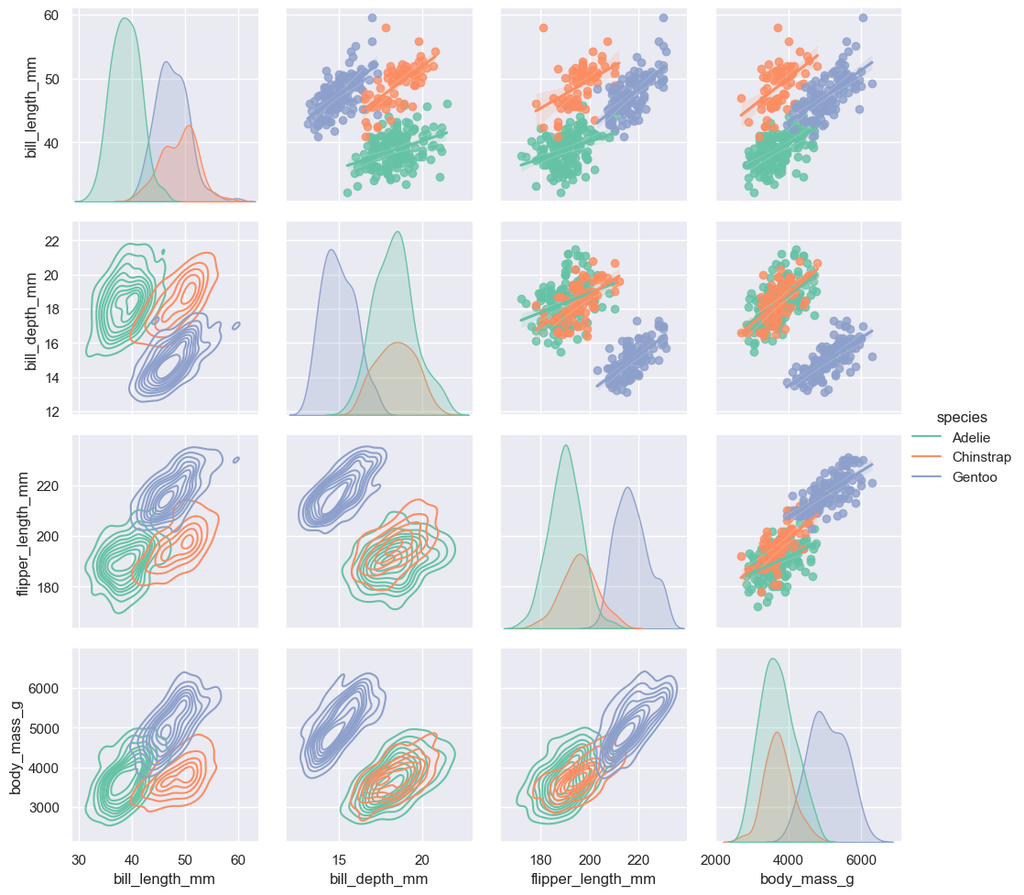

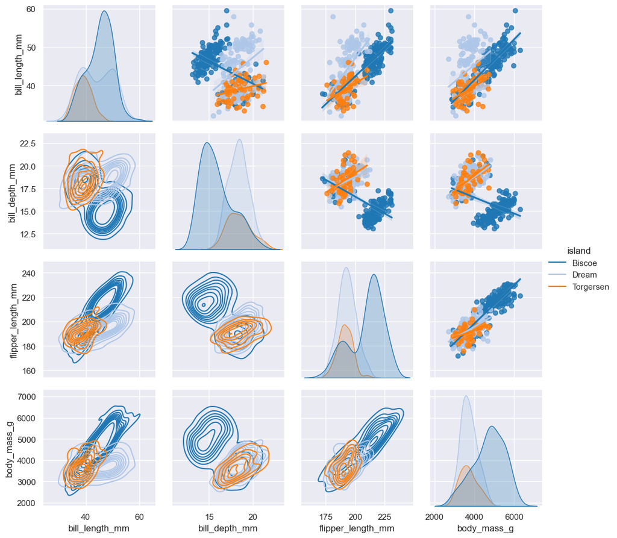

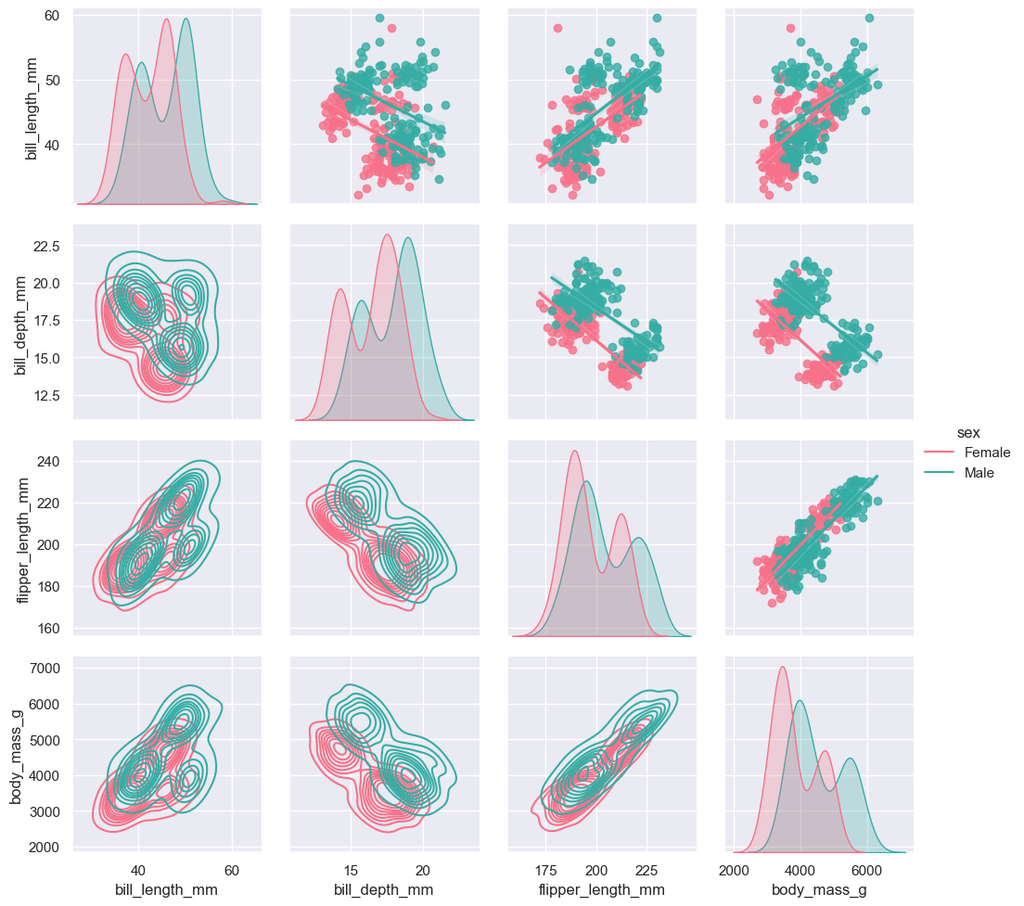

```python
palettes = (
    "Set2",
    "tab20",
    "husl",
)

for c, p in zip(category_columns, palettes):
    g = sns.PairGrid(
        df,
        hue=c,
        diag_sharey=False,
        palette=sns.color_palette(p, len(df[c].dropna().unique())),
    )
    g.map_upper(sns.regplot)
    g.map_lower(sns.kdeplot)
    g.map_diag(sns.kdeplot, fill=True)
    g.add_legend()
```

#### Correlation Matrix

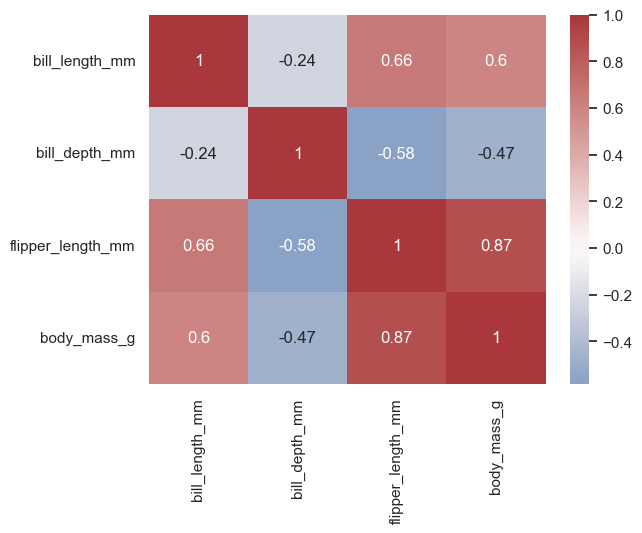

```python
fig = (
    df.select_dtypes("number")
    .corr()
    .pipe(sns.heatmap, annot=True, center=0, cmap="vlag")
)
```

## Statistical Analyses

### Hypothesis Testing

Let's take 20 samples from each species to test whether their means differ significantly from the population means for each species. The population means here represent the null hypothesis for each species.

We’ll run a power analysis to determine the minimum detectable effect size for our test, given a sample size of 20, a false-positive error rate of 5%, and a true-positive detection rate of 80%.

Imagine we don't know the sample's species: Our test can help us determine whether or not we think the sample came from the same species as the null population.

```python
import pprint

sample_size = 20
seed = 16273849
# seed = np.random.randint(0, 10000)

effect_size = TTestPower().solve_power(
    nobs=sample_size,
    alpha=0.05,
    power=0.80,
    alternative="two-sided",  # The sample mean can be higher or lower than the null population mean.
)

print(
    f"With a sample size of {sample_size}, we can reliably detect a resulting difference that is at least {effect_size:.3f} standard deviations from the population mean.",
    end="\n" * 2,
)

species_means = df.groupby("species", observed=False)["body_mass_g"].mean()
species_std_devs = df.groupby("species", observed=False)["body_mass_g"].std()
species_detectable_differences = species_std_devs * effect_size
species_detectable_pct_change = (species_std_devs * effect_size) / species_means
species_means_and_bounds = species_means.to_frame().assign(
    lower_threshold=species_means - species_detectable_differences,
    upper_threshold=species_means + species_detectable_differences,
)


print("Means and Minimum Thresholds:", species_means_and_bounds, sep="\n", end="\n" * 2)
print(
    "Detectable Differences ± From Mean:",
    species_detectable_differences,
    sep="\n",
    end="\n" * 2,
)
print(
    "Detectable % Change From Mean:",
    species_detectable_pct_change,
    sep="\n",
    end="\n" * 2,
)

print("Samples and tests:")
print("==================", end="\n" * 2)

for species in species_means.index:

    sample = (
        df.dropna(subset="body_mass_g")
        .query(f'species == "{species}"')["body_mass_g"]
        .sample(sample_size, random_state=seed)
    )
    print(
        f"{species} with sample mean of {sample.mean():.2f} and standard deviation of {sample.std():.2f}:"
    )

    print()

    results = {
        i: stats.ttest_1samp(sample, species_means[i]) for i in species_means.index
    }
    pprint.pprint(results)
    print()
```

```
With a sample size of 20, we can reliably detect a resulting difference that is at least 0.660 standard deviations from the population mean.

Means and Minimum Thresholds:
           body_mass_g  lower_threshold  upper_threshold
species
Adelie     3700.662252      3397.806078      4003.518425
Chinstrap  3733.088235      3479.257336      3986.919134
Gentoo     5076.016260      4743.076896      5408.955624

Detectable Differences ± From Mean:
species
Adelie       302.856173
Chinstrap    253.830899
Gentoo       332.939364
Name: body_mass_g, dtype: float64

Detectable % Change From Mean:
species
Adelie       0.081838
Chinstrap    0.067995
Gentoo       0.065591
Name: body_mass_g, dtype: float64

Samples and tests:
==================

Adelie with sample mean of 3695.00 and standard deviation of 580.92:

{'Adelie': TtestResult(statistic=np.float64(-0.04358973300588113), pvalue=np.float64(0.9656862839808528), df=np.int64(19)),
 'Chinstrap': TtestResult(statistic=np.float64(-0.2932148035994223), pvalue=np.float64(0.7725365040055188), df=np.int64(19)),
 'Gentoo': TtestResult(statistic=np.float64(-10.63148261830143), pvalue=np.float64(1.94533280072876e-09), df=np.int64(19))}

Chinstrap with sample mean of 3668.75 and standard deviation of 354.10:

{'Adelie': TtestResult(statistic=np.float64(-0.4030389634794061), pvalue=np.float64(0.691418720683808), df=np.int64(19)),
 'Chinstrap': TtestResult(statistic=np.float64(-0.8125661562480612), pvalue=np.float64(0.42653149293455983), df=np.int64(19)),
 'Gentoo': TtestResult(statistic=np.float64(-17.773209517023524), pvalue=np.float64(2.691066892192137e-13), df=np.int64(19))}

Gentoo with sample mean of 5070.00 and standard deviation of 550.51:

{'Adelie': TtestResult(statistic=np.float64(11.123901141849657), pvalue=np.float64(9.219029106607786e-10), df=np.int64(19)),
 'Chinstrap': TtestResult(statistic=np.float64(10.860486628623903), pvalue=np.float64(1.370321258972563e-09), df=np.int64(19)),
 'Gentoo': TtestResult(statistic=np.float64(-0.048873467026922315), pvalue=np.float64(0.9615302395195815), df=np.int64(19))}
```

#### Conclusions

1. The Adelie sample wouldn't be out of place in the Chinstrap population, but is a significant result if we assumed the Gentoo population.
2. The Chinstrap sample wouldn't be out of place in the Adelie population, but is a significant result if we assumed the Gentoo population.
3. The Gentoo sample couldn't be seen to come from either the Adelie or the Chinstrap populations, and the result is extreme enough for the test's sensitivity.

### Contingency Tables and Chi-Square Tests

Cross tabulation is a simple way to analyze categorical data on penguins. Here I'll take category columns pairwise to see what the frequencies we observe tell us about our dataset.

```python
import itertools

column_pairs = itertools.combinations(category_columns, r=2)

for p in column_pairs:

    col_a = p[0]
    col_b = p[1]

    contingency_table = df[[col_a, col_b]].pivot_table(
        index=col_a, columns=col_b, aggfunc="size", observed=False
    )

    chi2_results = stats.chi2_contingency(contingency_table)

    title = f"Contingency table of {col_a} by {col_b}."
    print(title)
    print("=" * len(title), end="\n" * 2)
    pprint.pprint(contingency_table)
    print()
    print(
        f"What's the probability of observing these frequencies if {col_a} and {col_b} are unrelated? {chi2_results.pvalue:.2f}."
    )
    print(
        """
Expected Frequencies:
---------------------
    """
    )
    pprint.pprint(chi2_results.expected_freq)
    print()
```

```
Contingency table of species by island.
=======================================

island     Biscoe  Dream  Torgersen
species
Adelie         44     56         52
Chinstrap       0     68          0
Gentoo        124      0          0

What's the probability of observing these frequencies if species and island are unrelated? 0.00.

Expected Frequencies:
---------------------

array([[74.23255814, 54.79069767, 22.97674419],
       [33.20930233, 24.51162791, 10.27906977],
       [60.55813953, 44.69767442, 18.74418605]])

Contingency table of species by sex.
====================================

sex        Female  Male
species
Adelie         73    73
Chinstrap      34    34
Gentoo         58    61

What's the probability of observing these frequencies if species and sex are unrelated? 0.98.

Expected Frequencies:
---------------------

array([[72.34234234, 73.65765766],
       [33.69369369, 34.30630631],
       [58.96396396, 60.03603604]])

Contingency table of island by sex.
===================================

sex        Female  Male
island
Biscoe         80    83
Dream          61    62
Torgersen      24    23

What's the probability of observing these frequencies if island and sex are unrelated? 0.97.

Expected Frequencies:
---------------------

array([[80.76576577, 82.23423423],
       [60.94594595, 62.05405405],
       [23.28828829, 23.71171171]])
```

#### Findings

- Male-Female splits evenly as expected across both island and species.
- Island could be a helpful variable in a species-classification model.
  - We would want to consult a subject matter expert before applying the model to unseen data.
    - Do these splits hold up outside our dataset?

## Modeling

### Data Processing

Preprocessing outside of tools like sklearn pipelines is bad practice.

1. Data leakage:
2. Data loss: Expecially for already-small datasets you don't want to lost observations you don't have to: imputation is always a good option.
3. DRY: Raises issues especially when you are forced to repeat yourself exactly on unseen data.

I'll continue the naïve route in the `statsmodels` models to show how what we're doing, whatever the tool, is simple. Frameworks used poorly can obfuscate when they mean to assist.

```python
import statsmodels.formula.api as smf
from sklearn.model_selection import train_test_split

df_processed = (
    sm.add_constant(df)
    .dropna(how="any")
    .assign(body_mass_kg=lambda df: df.body_mass_g / 1000)  # kg scale is relatable.
)

number_columns = df_processed.select_dtypes("number").columns
```

```python
# MM Scale caused warnings about condition number.
# Let's set those to meters:
meter_versions = df_processed.filter(like="mm") / 100
df_processed[meter_versions.columns.str.replace("mm", "m")] = meter_versions
```

This exists; don't code in antipatterns. Ever see someone juggle data named a, b, c, d for training and testing X's and Y's? I'm not even including the Y's separately here.

```python
train, test = train_test_split(df_processed, random_state=3)
```

By the way, we could standardize all the variables, but this would destroy the interpretability that we value in a simple linear regression. Better to save this for ML models that require it.

```python
# scaler = preprocessing.StandardScaler()
# df_processed[number_columns] = scaler.fit_transform(df_processed[number_columns])
```

## Linear Regression

Let's see how well we can predict body mass with a selection of the variables.

We would use recursive feature elimination and algorithmic feature selection if this data were much bigger.

```python
model_formula = "body_mass_kg ~ C(sex) + C(species) + bill_depth_m + flipper_length_m"

# Including island only increased our R-squared by 0.001 with higher Akaike and Bayesian ICs. I'll pass, thank you.
# model_formula_without_island = 'body_mass_kg ~ C(sex) + C(species) + C(island) + bill_depth_m + flipper_length_m'

model = smf.ols(formula=model_formula, data=train)
# model = smf.ols(formula=model_formula_without_island, data=train)
results = model.fit()
results.summary()
```

OLS Regression Results

| Dep. Variable: | body_mass_kg | R-squared: | 0.874 |
| --- | --- | --- | --- |
| Model: | OLS | Adj. R-squared: | 0.871 |
| Method: | Least Squares | F-statistic: | 336.3 |
| Date: | Thu, 14 Nov 2024 | Prob (F-statistic): | 5.33e-107 |
| Time: | 22:29:42 | Log-Likelihood: | -45.532 |
| No. Observations: | 249 | AIC: | 103.1 |
| Df Residuals: | 243 | BIC: | 124.2 |
| Df Model: | 5 |  |  |
| Covariance Type: | nonrobust |  |  |

|  | coef | std err | t | P>\|t\| | [0.025 | 0.975] |
| --- | --- | --- | --- | --- | --- | --- |
| Intercept | -1.1287 | 0.659 | -1.713 | 0.088 | -2.427 | 0.169 |
| C(sex)[T.Male] | 0.4158 | 0.051 | 8.120 | 0.000 | 0.315 | 0.517 |
| C(species)[T.Chinstrap] | -0.0596 | 0.053 | -1.130 | 0.260 | -0.164 | 0.044 |
| C(species)[T.Gentoo] | 1.2938 | 0.140 | 9.215 | 0.000 | 1.017 | 1.570 |
| bill_depth_m | 9.2713 | 2.305 | 4.023 | 0.000 | 4.732 | 13.811 |
| flipper_length_m | 1.5414 | 0.336 | 4.589 | 0.000 | 0.880 | 2.203 |

| Omnibus: | 0.888 | Durbin-Watson: | 2.133 |
| --- | --- | --- | --- |
| Prob(Omnibus): | 0.641 | Jarque-Bera (JB): | 0.949 |
| Skew: | 0.140 | Prob(JB): | 0.622 |
| Kurtosis: | 2.887 | Cond. No. | 293. |

Notes:  
[1] Standard Errors assume that the covariance matrix of the errors is correctly specified.

#### More Notes

Remember that p-values in the model summary are about the probability that the coefficient is zero, given all other included predictors. ANOVA p-values are about the predictors' overall significance in explaining the variance of the dependent variable. Yes, Chinstrap doesn't add much because it's so similar to the baseline Adelie, but the Gentoo's influence clarifies why species is important. Maybe we'll make a Gentoo flag to simplify the model, but I'm happy with how this demonstrates a few subtle considerations that go into composing a model.

#### ANOVA

All our inputs are statistically significant with the category variables explaining a large cut of the variation in penguin body mass.

```python
anova_results = sm.stats.anova_lm(results)
anova_results
```

|  | df | sum_sq | mean_sq | F | PR(>F) |
| --- | --- | --- | --- | --- | --- |
| C(sex) | 1.0 | 32.574063 | 32.574063 | 376.636396 | 2.643551e-51 |
| C(species) | 2.0 | 108.608450 | 54.304225 | 627.890592 | 9.976244e-97 |
| bill_depth_m | 1.0 | 2.431911 | 2.431911 | 28.118877 | 2.563635e-07 |
| flipper_length_m | 1.0 | 1.821693 | 1.821693 | 21.063252 | 7.127598e-06 |
| Residual | 243.0 | 21.016283 | 0.086487 | NaN | NaN |

Does this look familiar? Just a nice reminder for where `R-squared` comes from.

```python
1 - anova_results.loc["Residual", "sum_sq"] / anova_results.sum_sq.sum()
```

```
np.float64(0.8737399788212974)
```

### Model Evaluation

This pattern is useful for including many different metrics: a good candidate for the `bindle` package!

```python
true_results = test.body_mass_kg
predicted_results = results.predict(test)

metric_functions = [
    metrics.mean_absolute_percentage_error,
    metrics.r2_score,
]

pd.DataFrame(
    {
        "metric": map(lambda x: x.__name__, metric_functions),
        "value": [m(true_results, predicted_results) for m in metric_functions],
    }
)
```

|  | metric | value |
| --- | --- | --- |
| 0 | mean_absolute_percentage_error | 0.055456 |
| 1 | r2_score | 0.864166 |

Our model explains 86% of the variation in the test data and our predictions are off by ±5.5% on average.

#### Visual Follow-Ups

##### Q-Q Plot

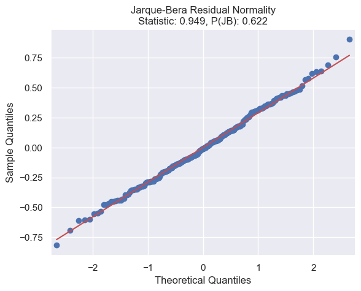

```python
# Including a calculation of JB - same result as in the model summary.
jb_result = stats.jarque_bera(results.resid)
title = f"Jarque-Bera Residual Normality\nStatistic: {jb_result.statistic:.3f}, P(JB): {jb_result.pvalue:.3f}"
fig = sm.qqplot(results.resid, line="s")
fig.axes[0].set_title(title)
```

Note the same Jarque-Bera score as above – only a graphical alternative.

##### VIF and Multicollinearity

```python
# Variance Inflation Factor
from statsmodels.stats.outliers_influence import variance_inflation_factor, OLSInfluence

exog_df = pd.DataFrame(model.exog, columns=model.exog_names).drop(columns="Intercept")

exog_df.shape[1]
vif_frame = pd.DataFrame(
    {
        "Variable": exog_df.columns,
        "VIF": [variance_inflation_factor(exog_df, i) for i in range(exog_df.shape[1])],
    }
)

vif_frame
```

|  | Variable | VIF |
| --- | --- | --- |
| 0 | C(sex)[T.Male] | 2.469499 |
| 1 | C(species)[T.Chinstrap] | 1.596826 |
| 2 | C(species)[T.Gentoo] | 18.260041 |
| 3 | bill_depth_m | 388.702697 |
| 4 | flipper_length_m | 473.607918 |

We have high scores for multicollinearity in all but the first two variables. Recall our first scatterplot matrix and, simply, see why in the KDE distributions that go down across the center:

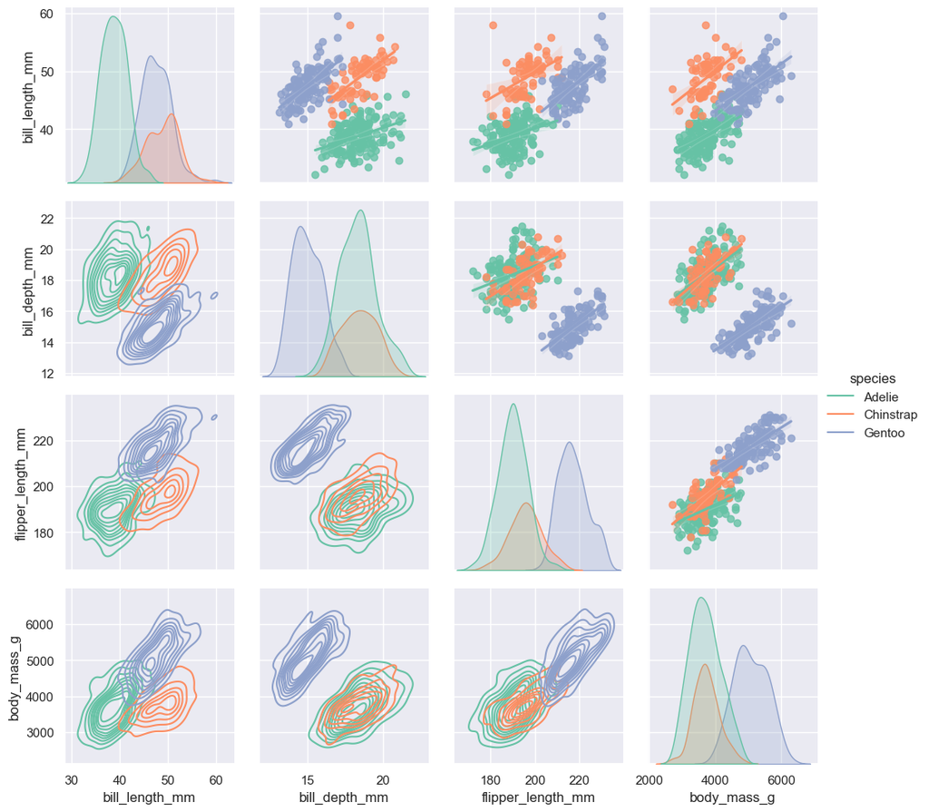

```python
g = sns.PairGrid(
    df,
    hue="species",
    diag_sharey=False,
    palette=sns.color_palette("Set2", len(df["species"].dropna().unique())),
)
g.map_upper(sns.regplot)
g.map_lower(sns.kdeplot)
g.map_diag(sns.kdeplot, fill=True)
g.add_legend()
```

##### Exploring the independent variables.

You can see the predictive power of Gentoo in that plot's slope. Conversely see how the Chinstrap flag doesn't do much with Adelie being the very-similar baseline.

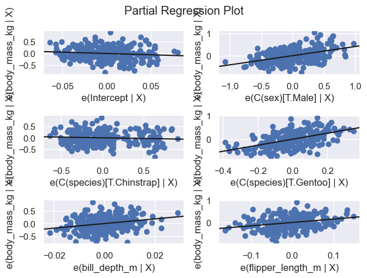

```python
fig = sm.graphics.plot_partregress_grid(results)
fig.tight_layout(pad=1)
```

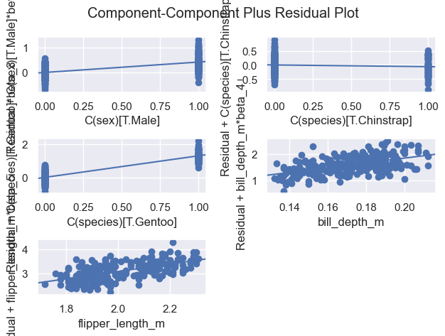

```python
fig = sm.graphics.plot_ccpr_grid(results)
fig.tight_layout(pad=1)
```

Data looks normal enough. Maybe some outliers, maybe a few leverage points (bill depth?). I'll use it as an example to seek out.

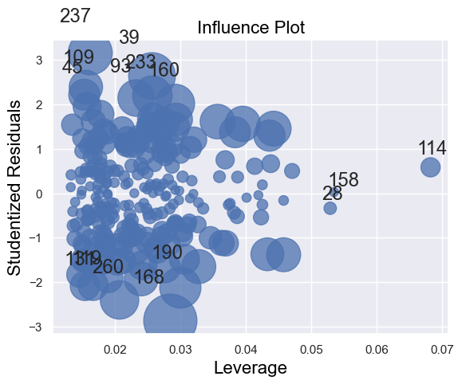

```python
fig = sm.graphics.influence_plot(results, "bill_depth_m")
```

##### Found it.

```python
train.loc[114]
```

```
const                   1.0
species              Adelie
island               Biscoe
bill_length_mm         39.6
bill_depth_mm          20.7
flipper_length_mm     191.0
body_mass_g          3900.0
sex                  Female
body_mass_kg            3.9
bill_length_m         0.396
bill_depth_m          0.207
flipper_length_m       1.91
Name: 114, dtype: object
```

```python
train.query("bill_depth_m > 0.2")
train.query('body_mass_kg > 3.8 and sex == "Female" and bill_depth_m > 0.15')
```

|  | const | species | island | bill_length_mm | bill_depth_mm | flipper_length_mm | body_mass_g | sex | body_mass_kg | bill_length_m | bill_depth_m | flipper_length_m |
| --- | --- | --- | --- | --- | --- | --- | --- | --- | --- | --- | --- | --- |
| 160 | 1.0 | Chinstrap | Dream | 46.0 | 18.9 | 195.0 | 4150.0 | Female | 4.150 | 0.460 | 0.189 | 1.95 |
| 332 | 1.0 | Gentoo | Biscoe | 43.5 | 15.2 | 213.0 | 4650.0 | Female | 4.650 | 0.435 | 0.152 | 2.13 |
| 157 | 1.0 | Chinstrap | Dream | 45.2 | 17.8 | 198.0 | 3950.0 | Female | 3.950 | 0.452 | 0.178 | 1.98 |
| 114 | 1.0 | Adelie | Biscoe | 39.6 | 20.7 | 191.0 | 3900.0 | Female | 3.900 | 0.396 | 0.207 | 1.91 |
| 322 | 1.0 | Gentoo | Biscoe | 47.2 | 15.5 | 215.0 | 4975.0 | Female | 4.975 | 0.472 | 0.155 | 2.15 |
| 187 | 1.0 | Chinstrap | Dream | 47.5 | 16.8 | 199.0 | 3900.0 | Female | 3.900 | 0.475 | 0.168 | 1.99 |
| 110 | 1.0 | Adelie | Biscoe | 38.1 | 16.5 | 198.0 | 3825.0 | Female | 3.825 | 0.381 | 0.165 | 1.98 |
| 188 | 1.0 | Chinstrap | Dream | 47.6 | 18.3 | 195.0 | 3850.0 | Female | 3.850 | 0.476 | 0.183 | 1.95 |

Caught below at the top is our culprit who might as well have been `24601`:

```python
influence = results.get_influence()
(influence.summary_frame().sort_values("hat_diag", ascending=False).head(5))
```

|  | dfb_Intercept | dfb_C(sex)[T.Male] | dfb_C(species)[T.Chinstrap] | dfb_C(species)[T.Gentoo] | dfb_bill_depth_m | dfb_flipper_length_m | cooks_d | standard_resid | hat_diag | dffits_internal | student_resid | dffits |
| --- | --- | --- | --- | --- | --- | --- | --- | --- | --- | --- | --- | --- |
| 114 | -0.077153 | -0.112716 | -0.039567 | 0.068440 | 0.138256 | -0.004708 | 0.004144 | 0.582831 | 0.068203 | 0.157683 | 0.582037 | 0.157468 |
| 158 | 0.003160 | -0.000311 | 0.004233 | 0.004034 | 0.001921 | -0.004524 | 0.000006 | 0.025214 | 0.053447 | 0.005991 | 0.025162 | 0.005979 |
| 28 | -0.037852 | 0.012532 | -0.003647 | -0.057915 | -0.040893 | 0.064172 | 0.001068 | -0.338854 | 0.052863 | -0.080054 | -0.338236 | -0.079908 |
| 24 | 0.092120 | 0.086395 | 0.000397 | -0.001373 | -0.054263 | -0.060442 | 0.002061 | 0.500476 | 0.047039 | 0.111192 | 0.499703 | 0.111020 |
| 13 | 0.058048 | 0.047340 | 0.053263 | -0.173316 | -0.250430 | 0.097629 | 0.015236 | -1.380965 | 0.045743 | -0.302350 | -1.383561 | -0.302919 |

#### Exploring independent variables individually.

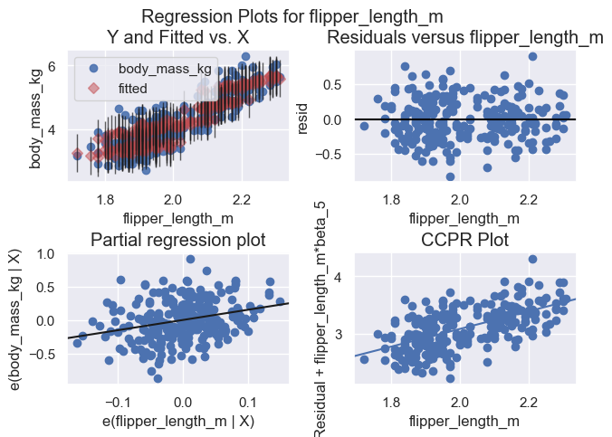

```python
fig = sm.graphics.plot_regress_exog(results, "flipper_length_m")
fig.tight_layout(pad=0.4)
```

### Logistic Regression

Let's review the data we have.

```python
train
```

|  | const | species | island | bill_length_mm | bill_depth_mm | flipper_length_mm | body_mass_g | sex | body_mass_kg | bill_length_m | bill_depth_m | flipper_length_m |
| --- | --- | --- | --- | --- | --- | --- | --- | --- | --- | --- | --- | --- |
| 291 | 1.0 | Gentoo | Biscoe | 46.4 | 15.6 | 221.0 | 5000.0 | Male | 5.000 | 0.464 | 0.156 | 2.21 |
| 168 | 1.0 | Chinstrap | Dream | 50.3 | 20.0 | 197.0 | 3300.0 | Male | 3.300 | 0.503 | 0.200 | 1.97 |
| 237 | 1.0 | Gentoo | Biscoe | 49.2 | 15.2 | 221.0 | 6300.0 | Male | 6.300 | 0.492 | 0.152 | 2.21 |
| 269 | 1.0 | Gentoo | Biscoe | 45.2 | 15.8 | 215.0 | 5300.0 | Male | 5.300 | 0.452 | 0.158 | 2.15 |
| 253 | 1.0 | Gentoo | Biscoe | 59.6 | 17.0 | 230.0 | 6050.0 | Male | 6.050 | 0.596 | 0.170 | 2.30 |
| ... | ... | ... | ... | ... | ... | ... | ... | ... | ... | ... | ... | ... |
| 284 | 1.0 | Gentoo | Biscoe | 45.8 | 14.2 | 219.0 | 4700.0 | Female | 4.700 | 0.458 | 0.142 | 2.19 |
| 263 | 1.0 | Gentoo | Biscoe | 49.6 | 15.0 | 216.0 | 4750.0 | Male | 4.750 | 0.496 | 0.150 | 2.16 |
| 137 | 1.0 | Adelie | Dream | 40.2 | 20.1 | 200.0 | 3975.0 | Male | 3.975 | 0.402 | 0.201 | 2.00 |
| 256 | 1.0 | Gentoo | Biscoe | 42.6 | 13.7 | 213.0 | 4950.0 | Female | 4.950 | 0.426 | 0.137 | 2.13 |
| 158 | 1.0 | Chinstrap | Dream | 46.1 | 18.2 | 178.0 | 3250.0 | Female | 3.250 | 0.461 | 0.182 | 1.78 |

249 rows × 12 columns

Yes, not 100% `sklearn` yet, but its components can assist a partially-pandas workflow.

```python
from sklearn.preprocessing import OneHotEncoder, LabelEncoder
from sklearn.pipeline import Pipeline
from sklearn.compose import ColumnTransformer

column_trans = ColumnTransformer(
    [
        ("labels", OneHotEncoder(drop=None), ["sex"]),
    ],
    remainder="passthrough",
    verbose_feature_names_out=False,
)

pipeline = Pipeline(
    [
        ("preprocessing", column_trans),
    ]
)

le = LabelEncoder()

scratch = pd.DataFrame(
    pipeline.fit_transform(train), columns=pipeline.get_feature_names_out()
).infer_objects()

scratch["species_code"] = le.fit_transform(scratch.species)
scratch["island_code"] = le.fit_transform(scratch.island)
scratch["sex"] = train.sex
scratch.info()
```

```
<class 'pandas.core.frame.DataFrame'>
RangeIndex: 249 entries, 0 to 248
Data columns (total 16 columns):
 #   Column             Non-Null Count  Dtype
---  ------             --------------  -----
 0   sex_Female         249 non-null    float64
 1   sex_Male           249 non-null    float64
 2   const              249 non-null    float64
 3   species            249 non-null    object
 4   island             249 non-null    object
 5   bill_length_mm     249 non-null    float64
 6   bill_depth_mm      249 non-null    float64
 7   flipper_length_mm  249 non-null    float64
 8   body_mass_g        249 non-null    float64
 9   body_mass_kg       249 non-null    float64
 10  bill_length_m      249 non-null    float64
 11  bill_depth_m       249 non-null    float64
 12  flipper_length_m   249 non-null    float64
 13  species_code       249 non-null    int64
 14  island_code        249 non-null    int64
 15  sex                182 non-null    category
dtypes: category(1), float64(11), int64(2), object(2)
memory usage: 29.7+ KB
```

### Classification

- Binary
  - True or false, yes or no, dog or not a dog.
- Multinomial
  - Strong, weakl indifferent; dog or cat or...penguin.

Let's focus on Multinomial with `mnlogit`.

```python
# formula_logit = 'male_ind ~ C(species) * body_mass_kg + bill_depth_m * bill_length_m'
formula_mnlogit = "species_code ~ body_mass_kg + bill_length_m + flipper_length_m"

# model = smf.logit(formula_logit, data=scratch)
model = smf.mnlogit(formula_mnlogit, data=scratch)

res = model.fit()
res.summary()
```

```
Optimization terminated successfully.
         Current function value: 0.032523
         Iterations 14
```

MNLogit Regression Results

| Dep. Variable: | species_code | No. Observations: | 249 |
| --- | --- | --- | --- |
| Model: | MNLogit | Df Residuals: | 241 |
| Method: | MLE | Df Model: | 6 |
| Date: | Thu, 14 Nov 2024 | Pseudo R-squ.: | 0.9695 |
| Time: | 22:29:45 | Log-Likelihood: | -8.0983 |
| converged: | True | LL-Null: | -265.11 |
| Covariance Type: | nonrobust | LLR p-value: | 7.990e-108 |

| species_code=1 | coef | std err | z | P>\|z\| | [0.025 | 0.975] |
| --- | --- | --- | --- | --- | --- | --- |
| Intercept | -118.3863 | 42.855 | -2.762 | 0.006 | -202.380 | -34.392 |
| body_mass_kg | -23.8309 | 10.567 | -2.255 | 0.024 | -44.543 | -3.119 |
| bill_length_m | 624.3293 | 257.188 | 2.428 | 0.015 | 120.249 | 1128.409 |
| flipper_length_m | -33.7558 | 24.076 | -1.402 | 0.161 | -80.945 | 13.433 |
| species_code=2 | coef | std err | z | P>\|z\| | [0.025 | 0.975] |
| Intercept | -194.8743 | 69.506 | -2.804 | 0.005 | -331.104 | -58.644 |
| body_mass_kg | 1.9915 | 3.596 | 0.554 | 0.580 | -5.057 | 9.040 |
| bill_length_m | 135.5036 | 67.412 | 2.010 | 0.044 | 3.379 | 267.628 |
| flipper_length_m | 62.5089 | 26.786 | 2.334 | 0.020 | 10.010 | 115.008 |

Adelie is our reference category. The remaining species are given their own coefficients to output to a probability. The species with the highest probability is the one predicted.

```python
scratch_test = pd.DataFrame(
    pipeline.fit_transform(test), columns=pipeline.get_feature_names_out()
).infer_objects()
scratch_test["species_code"] = le.fit_transform(scratch_test.species)
scratch_test["island_code"] = le.fit_transform(scratch_test.island)
scratch_test["sex"] = test.sex
scratch_test.info()
```

```
<class 'pandas.core.frame.DataFrame'>
RangeIndex: 84 entries, 0 to 83
Data columns (total 16 columns):
 #   Column             Non-Null Count  Dtype
---  ------             --------------  -----
 0   sex_Female         84 non-null     float64
 1   sex_Male           84 non-null     float64
 2   const              84 non-null     float64
 3   species            84 non-null     object
 4   island             84 non-null     object
 5   bill_length_mm     84 non-null     float64
 6   bill_depth_mm      84 non-null     float64
 7   flipper_length_mm  84 non-null     float64
 8   body_mass_g        84 non-null     float64
 9   body_mass_kg       84 non-null     float64
 10  bill_length_m      84 non-null     float64
 11  bill_depth_m       84 non-null     float64
 12  flipper_length_m   84 non-null     float64
 13  species_code       84 non-null     int64
 14  island_code        84 non-null     int64
 15  sex                23 non-null     category
dtypes: category(1), float64(11), int64(2), object(2)
memory usage: 10.2+ KB
```

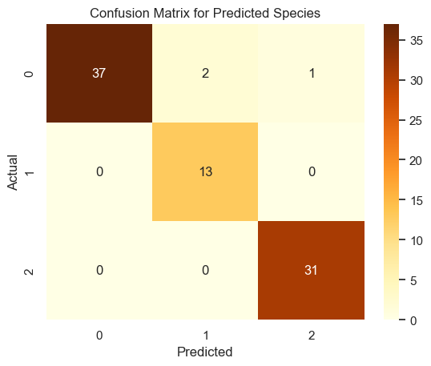

```python
from sklearn.metrics import confusion_matrix

predictions = np.argmax(res.predict(scratch_test), axis=1)
palette = sns.color_palette("YlOrBr", as_cmap=True)

ax = sns.heatmap(
    confusion_matrix(scratch_test.species_code, predictions), annot=True, cmap=palette
)
ax.set_title("Confusion Matrix for Predicted Species")
ax.set_ylabel("Actual")
ax.set_xlabel("Predicted")
```

## Unsupervised Learning.

What if we just want to split the data we have into two categories? K-Means clustering can do that.

```python
from sklearn.cluster import KMeans
from sklearn.preprocessing import StandardScaler
from sklearn.compose import make_column_selector, make_column_transformer
from sklearn.pipeline import make_pipeline

ct = make_column_transformer(
    (OneHotEncoder(), make_column_selector(dtype_include="category")),
    (StandardScaler(), make_column_selector(dtype_include="number")),
)

p = make_pipeline(
    ct,
    KMeans(n_clusters=2),
)

p
```

```
Pipeline(steps=[('columntransformer',
                 ColumnTransformer(transformers=[('onehotencoder',
                                                  OneHotEncoder(),
                                                  <sklearn.compose._column_transformer.make_column_selector object at 0x116326ea0>),
                                                 ('standardscaler',
                                                  StandardScaler(),
                                                  <sklearn.compose._column_transformer.make_column_selector object at 0x114da7260>)])),
                ('kmeans', KMeans(n_clusters=2))])
```

### Running the pipeline

```python
df_with_kmeans_groups = (
    df.dropna()
    .assign(kmeans_group=p.fit_predict(df.dropna()))
    .astype({"kmeans_group": "category"})
)
```

### Comparing the clusters

```python
df_with_kmeans_groups.groupby("kmeans_group", observed=False).describe().swaplevel(
    0, axis=1
).T.swaplevel()
```

|  | kmeans_group | 0 | 1 |
| --- | --- | --- | --- |
| bill_length_mm | count | 119.000000 | 214.000000 |
|  | mean | 47.568067 | 42.004673 |
|  | std | 3.106116 | 5.491545 |
|  | min | 40.900000 | 32.100000 |
|  | 25% | 45.350000 | 37.800000 |
|  | 50% | 47.400000 | 40.600000 |
|  | 75% | 49.600000 | 46.000000 |
|  | max | 59.600000 | 58.000000 |
| bill_depth_mm | count | 119.000000 | 214.000000 |
|  | mean | 14.996639 | 18.370561 |
|  | std | 0.985998 | 1.191134 |
|  | min | 13.100000 | 15.500000 |
|  | 25% | 14.200000 | 17.500000 |
|  | 50% | 15.000000 | 18.400000 |
|  | 75% | 15.750000 | 19.100000 |
|  | max | 17.300000 | 21.500000 |
| flipper_length_mm | count | 119.000000 | 214.000000 |
|  | mean | 217.235294 | 191.920561 |
|  | std | 6.585431 | 7.216846 |
|  | min | 203.000000 | 172.000000 |
|  | 25% | 212.000000 | 187.000000 |
|  | 50% | 216.000000 | 191.000000 |
|  | 75% | 221.500000 | 196.000000 |
|  | max | 231.000000 | 212.000000 |
| body_mass_g | count | 119.000000 | 214.000000 |
|  | mean | 5092.436975 | 3714.719626 |
|  | std | 501.476154 | 435.667063 |
|  | min | 3950.000000 | 2700.000000 |
|  | 25% | 4700.000000 | 3400.000000 |
|  | 50% | 5050.000000 | 3700.000000 |
|  | 75% | 5500.000000 | 3993.750000 |
|  | max | 6300.000000 | 4800.000000 |

```python
df_with_kmeans_groups.groupby("kmeans_group", observed=False).describe(
    include="category"
).swaplevel(0, axis=1).T.swaplevel()
```

|  | kmeans_group | 0 | 1 |
| --- | --- | --- | --- |
| species | count | 119 | 214 |
|  | unique | 1 | 2 |
|  | top | Gentoo | Adelie |
|  | freq | 119 | 146 |
| island | count | 119 | 214 |
|  | unique | 1 | 3 |
|  | top | Biscoe | Dream |
|  | freq | 119 | 123 |
| sex | count | 119 | 214 |
|  | unique | 2 | 2 |
|  | top | Male | Female |
|  | freq | 61 | 107 |

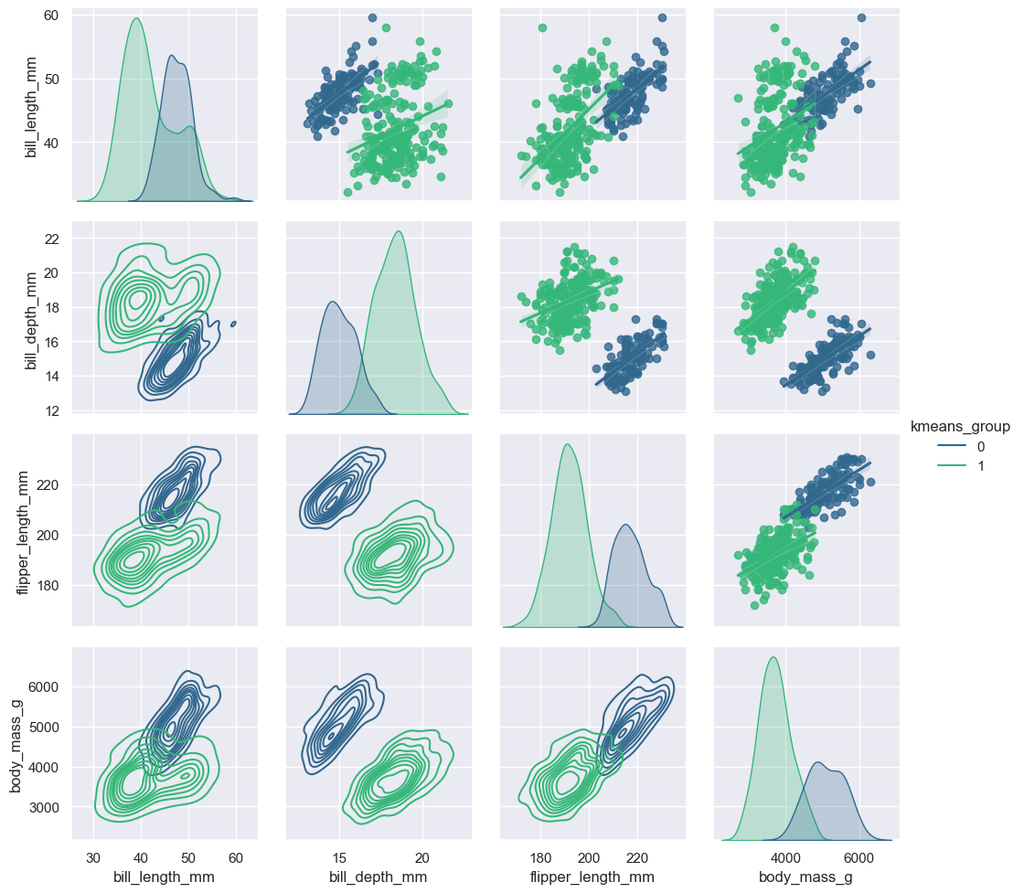

```python
g = sns.PairGrid(
    df_with_kmeans_groups,
    hue="kmeans_group",
    diag_sharey=False,
    palette=sns.color_palette("viridis", 2),
)
g.map_upper(sns.regplot)
g.map_lower(sns.kdeplot)
g.map_diag(sns.kdeplot, fill=True)
g.add_legend()
```

### Clustering Conclusion

And so ML techniques can do what we do visually: Adelie and Chinstrap had many similar metrics, they intermixed in our earlier scatterplots, and KMeans clustering agrees with us.

- We can use this to reduce dimesionality in our models.
- We can look for patterns after segmenting into N categories to guide further data mining.

Of course in our toy dataset this is easy to identify, and it's easy to think we could just group by "Gentoo versus everybody." But when the patterns become more subtle within dozens if not hundreds of variables, this is easier, faster, and more effective than memorizing all your data.